# 埼玉県 (議員定数：15 → 16)

アルゴリズムによる衆議院小選挙区の区割り改定案

ALARM Japan プロジェクトチーム  
July 4, 2022

**埼玉県**

人口： 7,183,326 人（2020年）

|  | 現行 | 新たな区割り | アルゴリズムの提案 |
| --- | --- | --- | --- |
| **1票の格差** |  |  |  |
| 県内較差 | 1.442 | 1.276 | 1.221 |
| 改善率 | - | 37.6% | 50.0% |
| **選挙区の状況** |  |  |  |
| 選挙区数 | 15 | 16 | 16 |
| 市区町村の分割 | 8<sup>a</sup> | 1<sup>b</sup> | 4<sup>c</sup> |
| 郡の分割 | 1<sup>d</sup> | 2<sup>e</sup> | 1<sup>d</sup> |
| 広域連携地域の分割 | 0 | 0 | 0 |

<sup>*a*</sup> さいたま市見沼区、熊谷市、 川口市、春日部市、鴻巣市、越谷市、久喜市、ふじみ野市 <sup>*b*</sup> 川口市 <sup>*c*</sup> 熊谷市、 川口市、鴻巣市、久喜市 <sup>*d*</sup> 入間郡 <sup>*e*</sup> 入間郡、北葛飾郡

# 現行の区割り

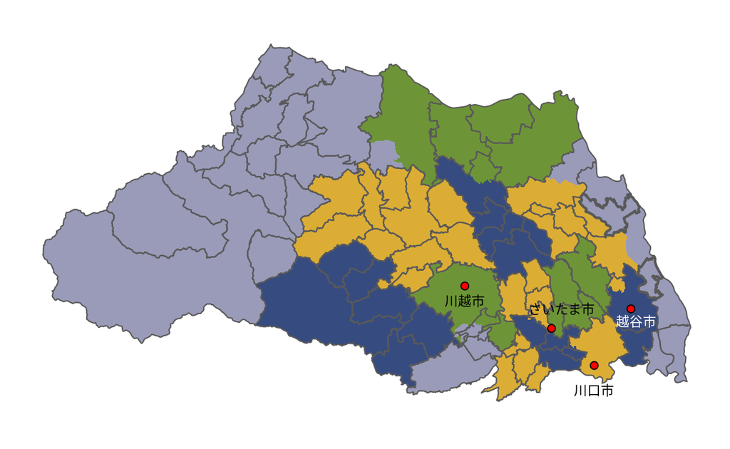

# アルゴリズムの提案

アルゴリズムが提案した5,000案のうち、一票の格差が最小のもの

一票の格差 : 1.221

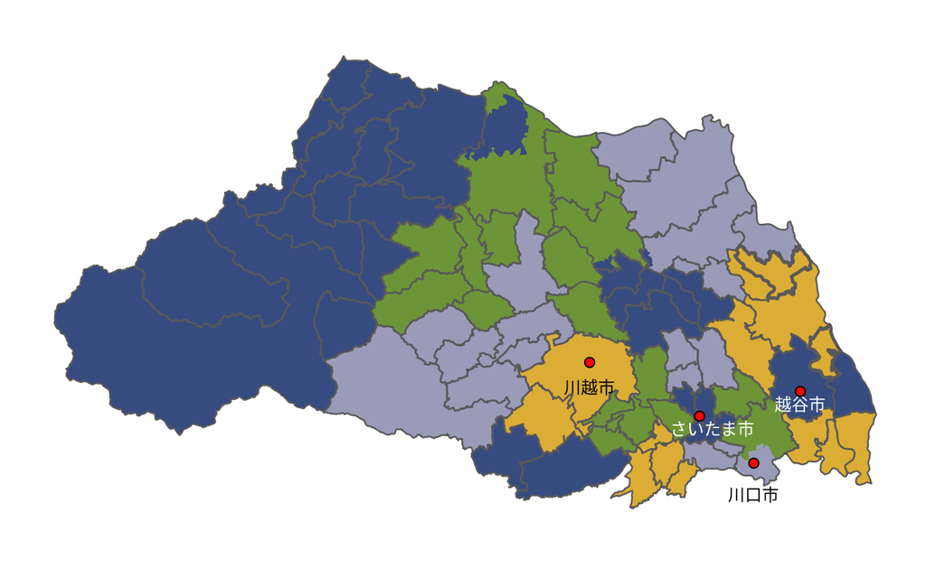

# 共起分析

- 有効な案のうち一票の格差が下位10％の案を抽出
- 隣接する地域と同じ選挙区に属する傾向が強い地域同士の集まりを、k = 30 設定
- 読み取り方  
  地図上の地域の色が
  - 同じ → 同じ選挙区に属する傾向が強い
  - 同じ かつ 濃い → 隣接する地域と同じ選挙区に属する傾向が強い

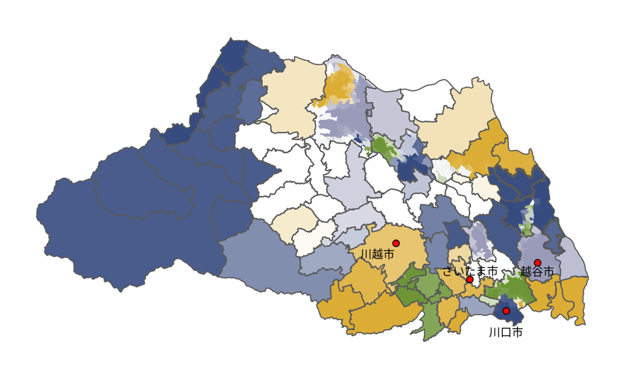

# アルゴリズム設定

- 各選挙区の人口 : (県内の日本人人口 / 選挙区数) ± 20%
- 市区町村を基本の単位として扱う
  - ただし、現状の区割りにおいて分割されている市区町村については、シミュレーションにおいても分割を許容し、国勢調査における小地域を基本の単位として扱う
  - 現状の区割りにおいて分割されている市区町村は、さいたま市見沼区、熊谷市、 川口市、春日部市、鴻巣市、越谷市、久喜市、ふじみ野市
- 市区町村の複数選挙区への分割の制限(`add_constr_multisplits`)と全体の分割数の制限(`add_constr_total_splits`)をそれぞれを設定
- 郡の分割は、現行の区割りにて分割されている場合のみ許容
- 離島は、航路で結ばれている本土の市区町村と同一の選挙区にする
- 逐次モンテカルロ法(SMC)による4つの独立したシミュレーションにより、区割り改定案を50,000作成
- 以下の案を棄却し有効な案を選定
  - 市区町村が3つ以上の選挙区に分割される案
  - 現状の区割りにおいて分割されていない郡・市区町村が分割される案
- 有効な案の中から5,000の案を無作為に抽出

### 県特有の設定

- 以下の地域は隣接するものとして扱った
  - 深谷市横瀬の一部は他県に囲われた飛び地だが、現行の区割りに従い、本プロジェクトも横瀬と地続きとして扱った
- 秩父郡は飛び地となっている。そのため、秩父市と合わせて一つのポリゴンとし、それをシュミレーションで用いることにより、飛び地が生じないようにした。

# データとプログラム

- [**Dataverse** : シュミレーションデータ](https://doi.org/10.7910/DVN/Z9UKSH)
- [**GitHub** : プログラム・コード](https://github.com/alarm-redist/japan)